# Writing Reports in Quarto using RStudio

# 5 Text formatting and emphasis

Use simple Markdown symbols to style your writing.

**Markdown syntax:**

```markdown
*italic text*
**bold text**
***bold and italic***
- Bullet list item
1. Numbered list item
```

**Rendered output:**

*italic text*  
**bold text**  
*bold and italic*

- Bullet list item
- Bullet list item 2
1. Numbered list item
2. Numbered list item 2

💡 You can also mix formatting in text, e.g.  
*The **results** show a strong correlation.*

# 6 The basic structure of a `.qmd` file

A simple Quarto document has three parts:

1. **YAML header** — defines document metadata (title, author, format), encased with `---`
2. **Markdown text** — where you write your report
3. **Code chunks** — where you include R/Python code and outputs

## 6.1 Example

**Markdown syntax:**

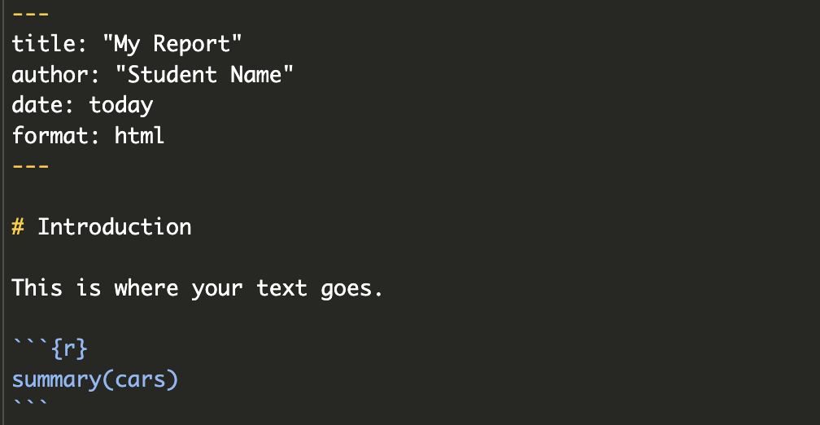

**Rendered output:**

# Introduction

This is where your text goes

```r
summary(cars)
```

```
     speed           dist
 Min.   : 4.0   Min.   :  2.00
 1st Qu.:12.0   1st Qu.: 26.00
 Median :15.0   Median : 36.00
 Mean   :15.4   Mean   : 42.98
 3rd Qu.:19.0   3rd Qu.: 56.00
 Max.   :25.0   Max.   :120.00
```

# 7 Understanding code chunks

A code chunk starts with three backticks followed by `{r}`, and ends with three backticks.

**Markdown syntax:**

[figure not shown]

**Rendered output:**

```r
library(tidyverse)
head(starwars)
```

```
# A tibble: 6 × 14
  name      height  mass hair_color skin_color eye_color birth_year sex   gender
  <chr>      <int> <dbl> <chr>      <chr>      <chr>          <dbl> <chr> <chr>
1 Luke Sky…    172    77 blond      fair       blue            19   male  mascu…
2 C-3PO        167    75 <NA>       gold       yellow         112   none  mascu…
3 R2-D2         96    32 <NA>       white, bl… red             33   none  mascu…
4 Darth Va…    202   136 none       white      yellow          41.9 male  mascu…
5 Leia Org…    150    49 brown      light      brown           19   fema… femin…
6 Owen Lars    178   120 brown, gr… light      blue            52   male  mascu…
# ℹ 5 more variables: homeworld <chr>, species <chr>, films <list>,
#   vehicles <list>, starships <list>
```

💡 Options can be added after `#|`, for example:

- `echo: false` → hide code
- `warning: false` → suppress warnings
- `fig-cap:` → add figure caption

For example:

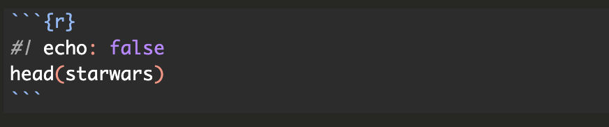

Will give the `head()` of the starwars dataset, but without explicitly printing the code to the document.

```
# A tibble: 6 × 14
  name      height  mass hair_color skin_color eye_color birth_year sex   gender
  <chr>      <int> <dbl> <chr>      <chr>      <chr>          <dbl> <chr> <chr>
1 Luke Sky…    172    77 blond      fair       blue            19   male  mascu…
2 C-3PO        167    75 <NA>       gold       yellow         112   none  mascu…
3 R2-D2         96    32 <NA>       white, bl… red             33   none  mascu…
4 Darth Va…    202   136 none       white      yellow          41.9 male  mascu…
5 Leia Org…    150    49 brown      light      brown           19   fema… femin…
6 Owen Lars    178   120 brown, gr… light      blue            52   male  mascu…
# ℹ 5 more variables: homeworld <chr>, species <chr>, films <list>,
#   vehicles <list>, starships <list>
```